# Coursework Report

*N* removed NAs: 3

*N* removed typo: 1

*N* removed <18: 21

*N* total clean: 125

| Group | *N* | *M*<sub>age</sub> | *M*<sub>rating</sub> |
| --- | --- | --- | --- |
| Control | 62 | 20.87 | 6.29 |
| Experim | 63 | 20.75 | 5.47 |

**Main analysis results**

*t*(123) = 5.97, *p* < .001

[interactive chart not shown]

[figure not shown]

[interactive chart not shown]

# Coursework Report

Analysing Data, Spring 2020

# Methods

## Design

The research question for this experiment is to examine the effect of the colours red and white on womens perceptions of attractiveness in men (Elliott et al,2010). Therefore the alternative hypothesis for this experiment is that the colour (white or red) of the background will effect the attractiveness rating of the man. The independent variable for this experiment is the colour of the background of the picture of the male, red or white. The dependent variable for this experiment is attractiveness. This was measured by three questions in which the participant rated on a 1-9 scale. Question 1 was ‘How attractive do you think the person is?’, question 2 was ‘How pleasant is this person to look at?’ and finally, question 3 was ‘If I were to meet the person in the picture face to face, I would think he was attractive’. The participant viewed the picture of a man on either the white (control) or red (experimental) background and had to rate each question, 1 being not at all attractive and 9 being extremely attractive. A t-test will be used in order to test the statistical significance of this experiment.

# Results

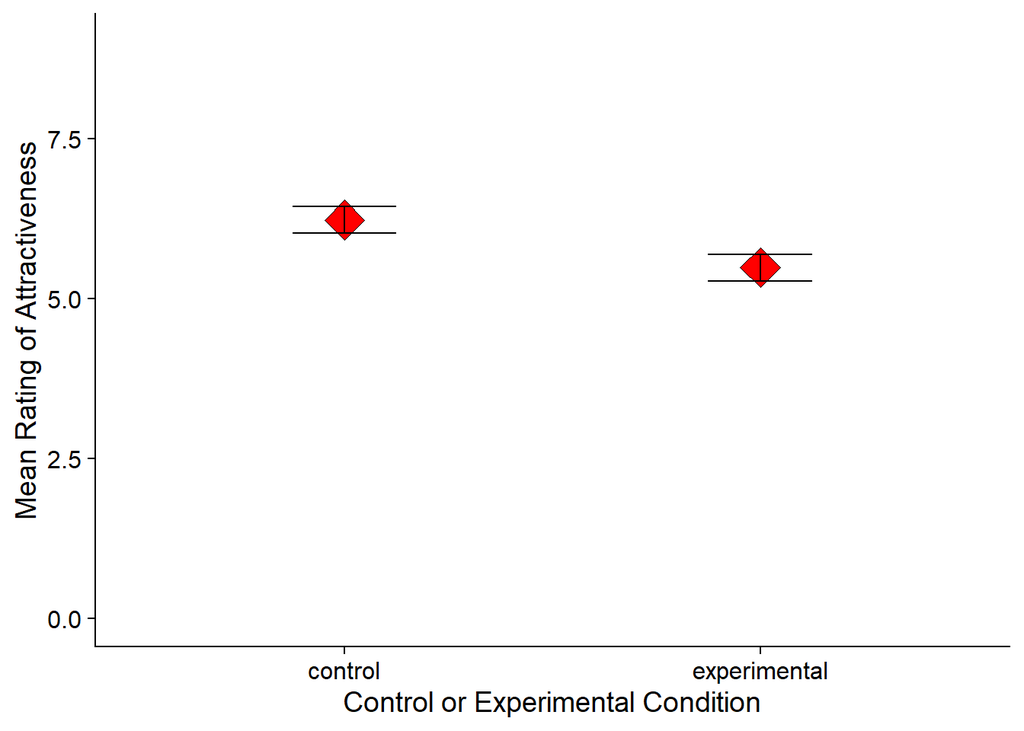

# Discussion

There are many limitations of this study. The main limitation of this study is that the study finds significant results but not in the way in which is expected by previous research. It could be argued that this could maybe be due to the fact that they used the colour white when comparing with the colour red. This is because the white would have provided more of a bright background contrast to the picture of the male, making the picture of the male stand out more and therefore influencing participants to rate the picture as more attractive. Another limitation is that the original sample contained many participants that were of an unethical age, therefore had to be removed from the study. This then meant that our sample was then smaller than expected and a larger sample makes for a more valid result. Another limitation of this study is that the maximum age of participants was 26. This therefore is unrepresentative of the general population and therefore the results can not necessarily be generalised to those older than 26.

Considering the findings of this experiment, there are many improvements that could be made in future research. One improvement that could be made to this experiment for further research is to show the picture on a different colour background instead of white when comparing with red, for example blue, as this would not have the same effect as the contrast of the image against the white background. Another idea for further research into this field is to ask different questions when the participant is looking at the photo of the male on the different colour backgrounds. This is because all of the questions that were asked, especially questions 1 and 2, were all very similar and therefore it is likely that each participant will answer similarly for each question. The researcher could instead ask ‘How similar does this person look to the type of person you are usually attracted to?’. Another possible way to improve this study would be to either try and do a repeated measures design or a matched pairs design. This would improve the study as every person has a different perception of attractiveness, so therefore, if the same person were to rate the attractiveness of the person on both the red and white background, then the results would be more reliable.

In conclusion, this study showed that there was a significant effect of colour on perceived attractiveness. However it was shown that the control group had a higher influence than the experimental group. This shows that the experiment needs to be replicated and further developed as this was not the result that was expected.

# References

Elliot, A. J., Niesta Kayser, D., Greitemeyer, T., Lichtenfeld, S., Gramzow, R. H., Maier, M. A., & Liu, H. (2010). Red, rank, and romance in women viewing men. *Journal of Experimental Psychology: General, 139*(3), 399.

Peperkoorn, L. S., Roberts, C., Pollet, T. V. (2016). Revisiting the Red Effect on Attractiveness and Sexual Receptivity: No Effect of the Colour Red on Human Mate Preferences *Evolutionary Psychology, 1-13.*